# 1st Assessment

Ram Krishna Pudasaini

2023-05-07

**Q 1. Explain how to import these type of data in R using the base r function**

- Comma Seperated values from text file
- Excel Data File
- SPSS data File

**To import CSV data in R,** you can use the read.csv() or read.csv2() functions from base R. The former function assumes that the comma (“,”) is used as the separator, while the latter assumes that the semicolon (“;”) is used as the separator.

Here’s an example code to import a CSV file named “data.csv” located in your working directory:

# Using read.csv()

*mydata <- read.csv(“data.csv”, header = TRUE)*

# Using read.csv2()

*mydata <- read.csv2(“data.csv”, header = TRUE)*

Note: We will use read.table’s alternative function

**To import data from an Excel file in R**, you can use the read.xlsx() or readxl::read_excel() functions. However, to use these functions, you need to install and load the “xlsx” and “readxl” packages respectively.

Here’s an example code to import an Excel file named “data.xlsx” located in your working directory:

# Using read.xlsx() from xlsx package

*library(xlsx)*

*mydata <- read.xlsx(“data.xlsx”, sheetIndex = 1)*

# Using read_excel() from readxl package

*library(readxl)*

*mydata <- read_excel(“data.xlsx”, sheet = 1)*

**To import an SPSS file (.sav) using the base R function**, you can use the foreign package, which provides the read.spss() function. Here’s an example code to import an SPSS file named “data.sav” located in your working directory:

# Load the foreign package

*library(foreign)*

# Import the data from the SPSS file

*mydata <- read.spss(“data.sav”, to.data.frame = TRUE)*

**QNo - 2 : Explain the following datatypes in R with examples and R codes**

- Numeric and Integer
- Categorical and Factor
- Date and Date as well as time

**Numeric and Integer data type** is used to represent real numbers with decimal points, while integer data type is used to represent whole numbers without decimal points. In R, you can create numeric and integer objects using the **numeric()** and **integer()** functions, respectively. Here are some examples:

```r
# Create a numeric object
x <- numeric(3)
x[1] <- 2.5
x[2] <- -1.3
x[3] <- 0.0
print(x) # Output: 2.5 -1.3 0
```

```
## [1]  2.5 -1.3  0.0
```

```r
# Create an integer object
y <- integer(4)
y[1] <- 10
y[2] <- -5
y[3] <- 0
y[4] <- 100
print(y) # Output:  10 -5  0 100
```

```
## [1]  10  -5   0 100
```

```r
# Create a numeric object
x <- numeric(3)
x[1] <- 2.5
x[2] <- -1.3
x[3] <- 0.0
print(x) # Output: 2.5 -1.3 0
```

```
## [1]  2.5 -1.3  0.0
```

```r
# Create an integer object
y <- integer(4)
y[1] <- 10
y[2] <- -5
y[3] <- 0
y[4] <- 100
print(y) # Output:  10 -5  0 100
```

```
## [1]  10  -5   0 100
```

**Categorical data type** is used to represent data that takes on a limited number of possible values, such as “male” or “female” for gender, while **factor data type** is used to represent categorical data that has specific levels or categories. In R, you can create categorical and factor objects using the factor() function. Here are some examples:

```r
# Create a categorical object
z <- c("red", "green", "blue", "red", "blue")
z_cat <- as.factor(z)
print(z_cat) # Output: red green blue red blue
```

```
## [1] red   green blue  red   blue
## Levels: blue green red
```

```r
# Levels: blue green red

# Create a factor object
w <- c("small", "medium", "large", "small", "medium")
w_fac <- factor(w, levels = c("small", "medium", "large"))
print(w_fac) # Output: small medium large small medium
```

```
## [1] small  medium large  small  medium
## Levels: small medium large
```

```r
# Levels: small medium large
```

**Date and Date as well as time:**

Date data type is used to represent calendar dates, while date and time data type is used to represent both the date and time of day. In R, you can create date and date/time objects using the as.Date() and as.POSIXct() functions, respectively. Here are some examples:

```r
# Create a date object

mydate <- as.Date("2023-05-07")
print(mydate) # Output: 2023-05-07
```

```
## [1] "2023-05-07"
```

```r
# Create a date/time object

mydatetime <- as.POSIXct("2023-05-07 10:15:30")
print(mydatetime) # Output: 2023-05-07 10:15:30 UTC# Create a date object
```

```
## [1] "2023-05-07 10:15:30 +0545"
```

**QNo: 3 Explain these terms with example in R codes**

- Array aand Matrix
- List and Unlist
- Dataframe and data table

**Array and Matrix:**

Both arrays and matrices are used to store data in a structured way in R. An array is a multi-dimensional object that can store data of the same type, while a matrix is a specific type of array that has only two dimensions. In R, you can create arrays and matrices using the array() and matrix() functions, respectively. Here are some examples:

```r
# Create an array
arr <- array(c(1, 2, 3, 4, 5, 6), dim = c(2, 3))
print(arr)
```

```
##      [,1] [,2] [,3]
## [1,]    1    3    5
## [2,]    2    4    6
```

```r
# Create a matrix
mat <- matrix(c(1, 2, 3, 4), nrow = 2, ncol = 2)
print(mat)
```

```
##      [,1] [,2]
## [1,]    1    3
## [2,]    2    4
```

**List and unlist:**

A list is a flexible object in R that can store data of different types and sizes. You can think of a list as a container that can hold many objects of different shapes and sizes. On the other hand, unlist() function is used to convert a list into a vector by concatenating its elements. Here are some examples:

```r
# Create a list
mylist <- list(a = 1, b = "two", c = c(3, 4, 5))
print(mylist) # Output:
```

```
## $a
## [1] 1
##
## $b
## [1] "two"
##
## $c
## [1] 3 4 5
```

```r
# Unlist a list
myvec <- unlist(mylist)
print(myvec) # Output: 1      two      3      4      5
```

```
##     a     b    c1    c2    c3
##   "1" "two"   "3"   "4"   "5"
```

**Dataframe and datatable:**

Both dataframes and data tables are used to store tabular data in R. A dataframe is a data structure with rows and columns, where each column can have a different data type. Data table is a more efficient and faster version of dataframe. In R, you can create dataframes and data tables using the data.frame() function and data.table() function, respectively. Here are some examples:

```r
# Create a dataframe
df <- data.frame(id = c(1, 2, 3), name = c("John", "Jane", "Joe"), age = c(25, 30, 35))
print(df)
```

```
##   id name age
## 1  1 John  25
## 2  2 Jane  30
## 3  3  Joe  35
```

```r
# Create a data table
library(data.table)
dt <- data.table(id = c(1, 2, 3), name = c("John", "Jane", "Joe"), age = c(25, 30, 35))
print(dt)
```

```
##    id name age
## 1:  1 John  25
## 2:  2 Jane  30
## 3:  3  Joe  35
```

**Qno: 4 Explain the following with examples in R code**

- Base R Code vs pipe operator code
- For loop code vs pipe operator code
- tee pipe operator vs exposition pipe operator

**Base R Code vs Pipe Operator Code:**

Base R code refers to the traditional way of writing R code using functions and operators, while the pipe operator (%>%) is a powerful feature in the magrittr package that allows you to chain multiple operations together in a more concise and readable way. Here is an example of base R code and pipe operator code for the same task:

```r
# Base R code
x <- c(1, 2, 3, 4, 5)
y <- sum(sqrt(x))

# Pipe operator code
library(magrittr)
x %>% sqrt() %>% sum() -> y
```

**For Loop Code vs Pipe Operator Code:**

A for loop is a common programming construct that allows you to iterate over a sequence of values and perform some operations on each element. The pipe operator can be used to replace for loops in some cases, especially when you need to perform a series of operations on a dataset. Here is an example of for loop code and pipe operator code for the same task:

```r
# For loop code
x <- 1:10
y <- vector("numeric", length(x))
for(i in seq_along(x)) {
  y[i] <- sqrt(x[i])
}

# Pipe operator code
x %>% sqrt() -> y
```

**Tee Pipe Operator vs Exposition Pipe Operator:**

The tee pipe operator (%T>%) and exposition pipe operator (%$%) are two variations of the pipe operator that can be used for different purposes. The tee pipe operator allows you to pipe a dataset to multiple functions simultaneously and return the original dataset, while the exposition pipe operator allows you to access variables in the dataset directly without the need to use the $ operator. Here are some examples:

```r
# Tee pipe operator
iris %T>%
  head() %>%
  tail()
```

```
##     Sepal.Length Sepal.Width Petal.Length Petal.Width   Species
## 145          6.7         3.3          5.7         2.5 virginica
## 146          6.7         3.0          5.2         2.3 virginica
## 147          6.3         2.5          5.0         1.9 virginica
## 148          6.5         3.0          5.2         2.0 virginica
## 149          6.2         3.4          5.4         2.3 virginica
## 150          5.9         3.0          5.1         1.8 virginica
```

```r
# Exposition pipe operator
iris %$%
  mean(Sepal.Length) -> avg_sepal_length
print(avg_sepal_length)
```

```
## [1] 5.843333
```

**QNo: 5 Explain the following in R with Example**

- Package
- Installation of Package
- Development of Package

**Package:**

In R, a package is a collection of functions, data, and documentation that can be easily shared and reused by others. R packages provide a convenient way to organize and distribute R code and can be used to extend the functionality of R for specific purposes. There are thousands of R packages available on CRAN (Comprehensive R Archive Network) and other repositories.

**Installation of Package:**

Developing an R package involves creating a set of functions, data, and documentation, and bundling them together in a standardized way. This can be done using the devtools package, which provides a set of tools for package development.

**Group B**

**Question 6: Do the following in R**

- Define integers feom 1 to 15 using three different coding approach as store as I
- Define these five numbers: 1.1, 2.2, 3.3, 4.4, 5.55 and save it in N
- Add Substract, multiply and divide I from N and Inteprete the result carefully
- Perform the matrix multiplication of I and N and inteprete the result carefully
- Transpose I and N and Perform Matrix multiplication and intepret the result carefully .

```r
# Define integers 1 to 15 using different coding approaches
I <- 1:15
I <- seq(1, 15, 1)
I <- rep(1:15, each = 1)

# Define numbers 1.1, 2.2, 3.3, 4.4, 5.55 and save it in N
N <- c(1.1, 2.2, 3.3, 4.4, 5.55)
```

```r
# Add, subtract, multiply and divide I from N
add <- I + N
subtract <- I - N
multiply <- I * N
divide <- I / N
```

```r
# Interpret the results of the arithmetic operations
# Adding I to N concatenates the two vectors together element-wise
add
```

```
##  [1]  2.10  4.20  6.30  8.40 10.55  7.10  9.20 11.30 13.40 15.55 12.10 14.20
## [13] 16.30 18.40 20.55
```

```r
# Subtracting N from I also subtracts each element of N from the corresponding element of I
subtract
```

```
##  [1] -0.10 -0.20 -0.30 -0.40 -0.55  4.90  4.80  4.70  4.60  4.45  9.90  9.80
## [13]  9.70  9.60  9.45
```

```r
# Multiplying I and N multiplies each element of I by each element of N
multiply
```

```
##  [1]  1.10  4.40  9.90 17.60 27.75  6.60 15.40 26.40 39.60 55.50 12.10 26.40
## [13] 42.90 61.60 83.25
```

```r
# Dividing I by N divides each element of I by the corresponding element of N
divide
```

```
##  [1]  0.9090909  0.9090909  0.9090909  0.9090909  0.9009009  5.4545455
##  [7]  3.1818182  2.4242424  2.0454545  1.8018018 10.0000000  5.4545455
## [13]  3.9393939  3.1818182  2.7027027
```

Performing Matrix multiplication

```r
# Perform matrix multiplication of I and N
#matmul <- I %*% N  #unable to perform operation as no of row not equals to num of col
#thus doint transpose of N and Doing multliplication
matmul <- I %*% t(N)
matmul
```

```
##       [,1] [,2] [,3] [,4]  [,5]
##  [1,]  1.1  2.2  3.3  4.4  5.55
##  [2,]  2.2  4.4  6.6  8.8 11.10
##  [3,]  3.3  6.6  9.9 13.2 16.65
##  [4,]  4.4  8.8 13.2 17.6 22.20
##  [5,]  5.5 11.0 16.5 22.0 27.75
##  [6,]  6.6 13.2 19.8 26.4 33.30
##  [7,]  7.7 15.4 23.1 30.8 38.85
##  [8,]  8.8 17.6 26.4 35.2 44.40
##  [9,]  9.9 19.8 29.7 39.6 49.95
## [10,] 11.0 22.0 33.0 44.0 55.50
## [11,] 12.1 24.2 36.3 48.4 61.05
## [12,] 13.2 26.4 39.6 52.8 66.60
## [13,] 14.3 28.6 42.9 57.2 72.15
## [14,] 15.4 30.8 46.2 61.6 77.70
## [15,] 16.5 33.0 49.5 66.0 83.25
```

This results in a 15x5 matrix, where each row of the matrix is the vector N multiplied by the corresponding element of I.

Transpose I and N and Perform Matrix multiplication and intepret the result carefully .

```r
tI <- t(I)
tN <- t(N)
#matmul2 <- tI %*% tN #unable to multiply due to matrix multiplication rule
#i.e number of rows of 1st matrix should be equal to number of col of second matrix
```

**Question 7 : Do the following in r**

- Load the inbuilt “airquality” data abvaliable in r ans store it as AQ object

  ```r
  # Load airquality data and save it as AQ object
  AQ <- airquality
  ```

- Check the structure of AQ and explain calss of the variables

  ```r
  # Check structure of AQ
  str(AQ)
  ```

  ```
  ## 'data.frame':    153 obs. of  6 variables:
  ##  $ Ozone  : int  41 36 12 18 NA 28 23 19 8 NA ...
  ##  $ Solar.R: int  190 118 149 313 NA NA 299 99 19 194 ...
  ##  $ Wind   : num  7.4 8 12.6 11.5 14.3 14.9 8.6 13.8 20.1 8.6 ...
  ##  $ Temp   : int  67 72 74 62 56 66 65 59 61 69 ...
  ##  $ Month  : int  5 5 5 5 5 5 5 5 5 5 ...
  ##  $ Day    : int  1 2 3 4 5 6 7 8 9 10 ...
  ```

  **Interpretation:** # AQ is a data.frame containing 153 observations of 6 variables. # The variables are a mix of integer and numeric data types. # Ozone, Solar.R, Temp, Month, and Day are integers, and Wind is numeric.
- Replace the missing value of Ozone variable with median of this variable

  ```r
  sum(is.na(AQ$Ozone))  #Checking the null value
  ```

  ```
  ## [1] 37
  ```

  ```r
  # Replace missing value of Ozone with median of the variable
  #AQ$Ozone[is.na(AQ$Ozone)] <- median(AQ$Ozone, na.rm = TRUE)

  #can be done like this as well
  library(tidyr)
  AQ$Ozone <- as.double(AQ$Ozone)
  AQ$Ozone <- replace_na(AQ$Ozone, median(AQ$Ozone, na.rm = TRUE))
  sum(is.na(AQ$Ozone))  #verifying the null value
  ```

  ```
  ## [1] 0
  ```

- Replace the missing value of Solar.R variable with mean of this variable

  ```r
  sum(is.na(AQ$Solar.R))  #Checking the null value
  ```

  ```
  ## [1] 7
  ```

  ```r
  # Replace missing value of Solar.R with mean of the variable
  AQ$Solar.R[is.na(AQ$Solar.R)] <- mean(AQ$Solar.R, na.rm = TRUE)
  sum(is.na(AQ$Solar.R))  #Verifying the null value
  ```

  ```
  ## [1] 0
  ```

- Create the “Date” Variable on AQ object using the months and dat variable for the year 2020

  ```r
  # Create Date variable for the year 2020
  AQ$Date <- as.Date(paste("2020", AQ$Month,AQ$Day, sep = "-"), format = "%Y-%m-%d")
  head(AQ)
  ```

  ```
  ##   Ozone  Solar.R Wind Temp Month Day       Date
  ## 1  41.0 190.0000  7.4   67     5   1 2020-05-01
  ## 2  36.0 118.0000  8.0   72     5   2 2020-05-02
  ## 3  12.0 149.0000 12.6   74     5   3 2020-05-03
  ## 4  18.0 313.0000 11.5   62     5   4 2020-05-04
  ## 5  31.5 185.9315 14.3   56     5   5 2020-05-05
  ## 6  28.0 185.9315 14.9   66     5   6 2020-05-06
  ```

**Question 8 : Use the clean AQ objects to do the following in r**

- Create the line plot of “Temp” with “Day” as the row index and interpret it carefully

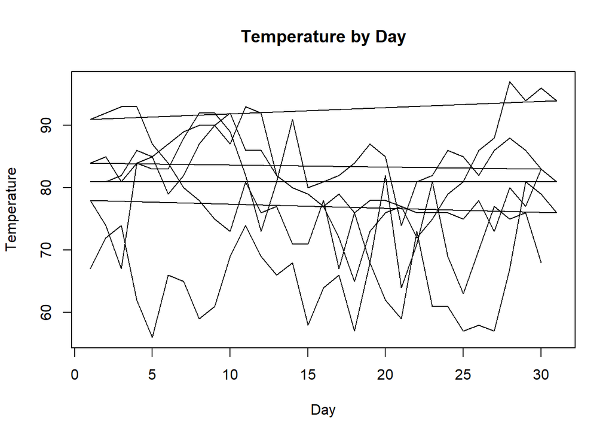

  ```r
  # Create line plot of Temp with Day as the x-axis
  plot(AQ$Day, AQ$Temp, type = "l", xlab = "Day", ylab = "Temperature", main = "Temperature by Day")
  ```

- Create the bar plot of Temp variable after defining class interval systematically

  ```r
  #determining the range
  range(AQ$Temp)   #56 97
  ```

  ```
  ## [1] 56 97
  ```

  ```r
  (R <- 97 - 56)
  ```

  ```
  ## [1] 41
  ```

  ```r
  (interval <- round(sqrt(R)))
  ```

  ```
  ## [1] 6
  ```

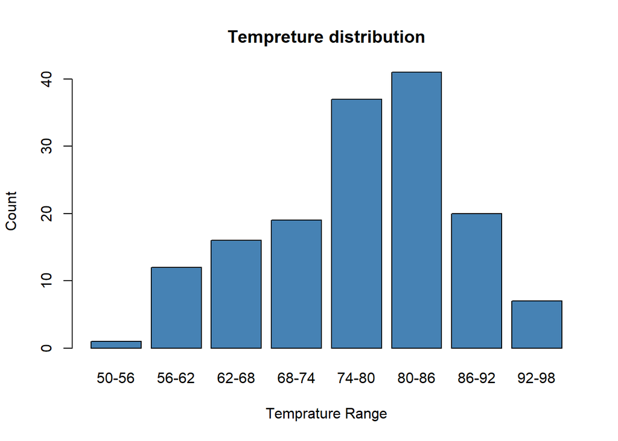

  ```r
  #Setting the class interval
  class_intervals <- seq(50, 100, by = 6)

  #ploting in the bar
  Temp_plot <- cut(AQ$Temp, class_intervals, labels = c("50-56", "56-62","62-68", "68-74","74-80","80-86","86-92","92-98"))

  barplot(table(Temp_plot), main = "Tempreture distribution", xlab = "Temprature Range", ylab = "Count", col = "steelblue")
  ```

  ```r
  #this can be done using this single line as well
  #barplot(table(cut(AQ$Temp, breaks = class_intervals, labels = c("50-56", "56-62","62-68", "68-74","74-80","80-86","86-92","92-98"))), xlab = "Temperature Range", ylab = "Count", main = "Temperature Distribution", col = "steelblue")
  ```

- Create the histogram of “Temp” Variable and compare it with the bar plot of “temp” variable

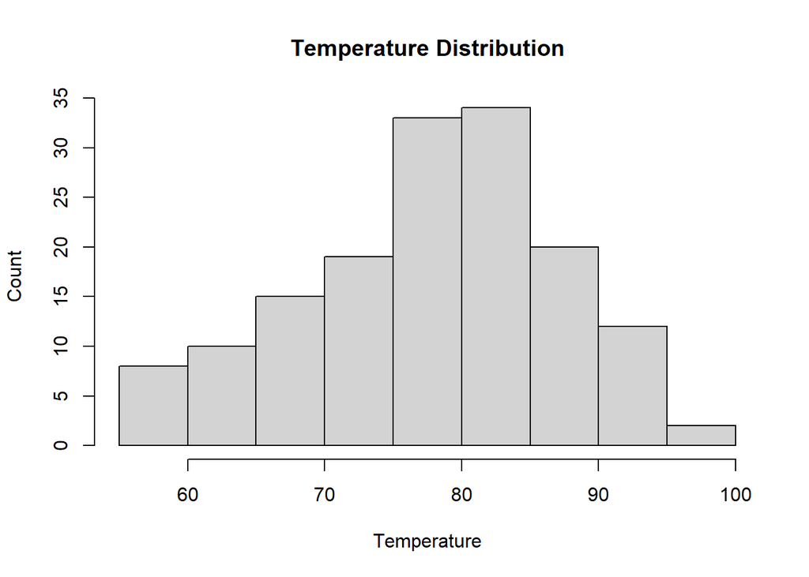

  ```r
  # Create histogram of Temp variable with defined class intervals
  hist(AQ$Temp, xlab = "Temperature", ylab = "Count", main = "Temperature Distribution")
  ```

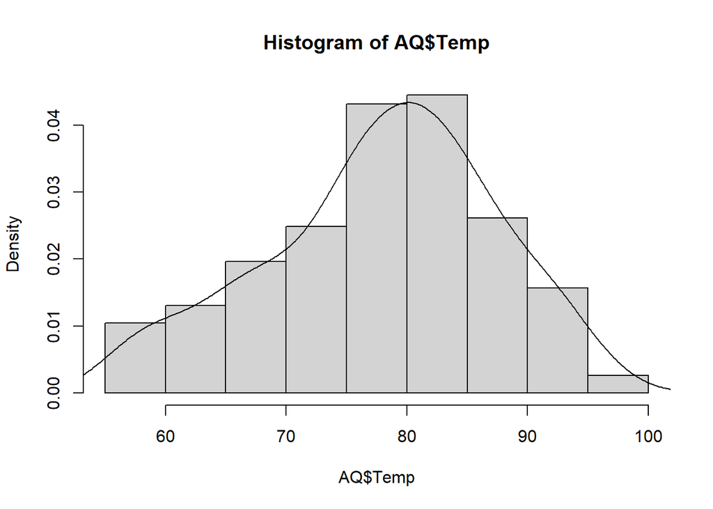

  ```r
  #give histogram with the density line
  hist(AQ$Temp, probability = TRUE)
  lines(density(AQ$Temp))
  ```

- Plot Normal QQ plot of temp variable and intepret it carefully

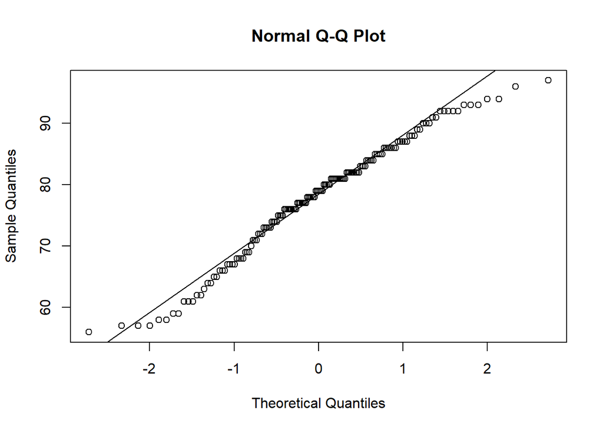

  ```r
  # Create normal QQ plot of Temp
  qqnorm(AQ$Temp)
  qqline(AQ$Temp)
  ```

  Since most of the data are align in the line we can say that it is normally distributed and we can use the linear model for this data.
- Create the scatter plot of “Temp” and “Wind” variable an interpret it carefully

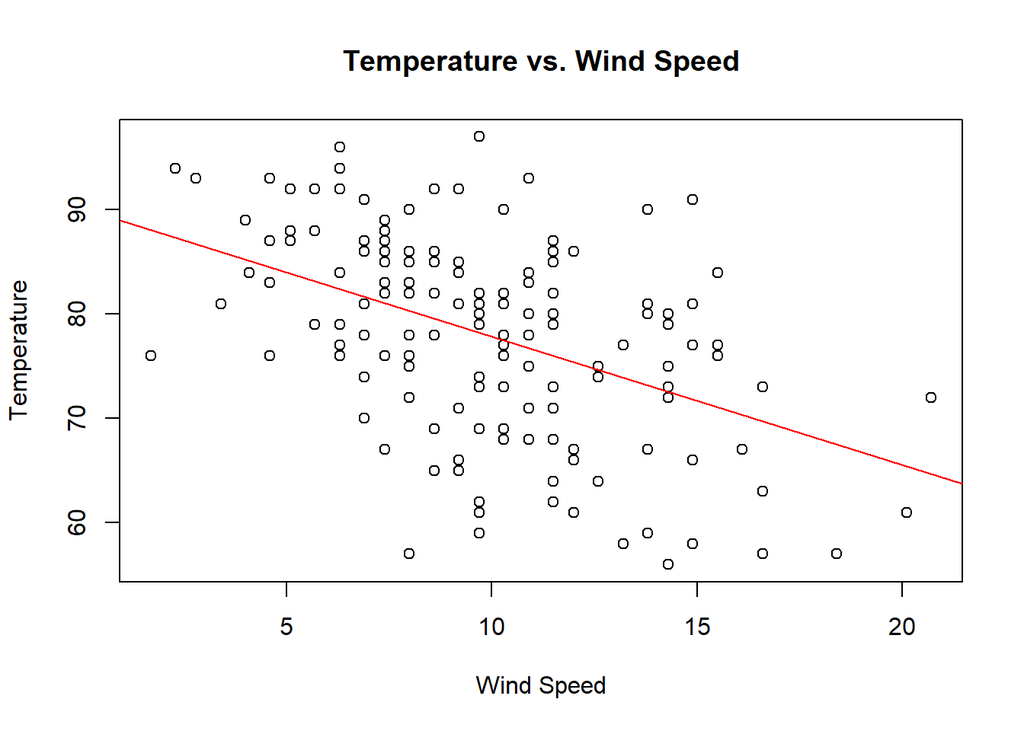

  ```r
  # Create scatter plot of Temp and Wind variables
  plot(AQ$Wind, AQ$Temp, xlab = "Wind Speed", ylab = "Temperature", main = "Temperature vs. Wind Speed")

  # Add regression line to scatter plot
  abline(lm(AQ$Temp ~ AQ$Wind), col = "red")
  ```

The scatter plot shows the relationship between the Temp and Wind variables. The xlab and ylab arguments specify the x-axis and y-axis labels, and the main argument specifies the plot title.

It’s also worth noting that there are a few outliers in the data where wind speed is high but temperature is still relatively high. These outliers suggest that there may be other factors affecting temperature beyond just wind speed.

**Question 9 : Use the clean AQ file in R and do the following**

- Get reference range of “Temp” Variable using mean and standard deviation

  ```r
  # Calculate mean and standard deviation of Temp variable
  temp_mean <- mean(AQ$Temp)
  temp_sd <- sd(AQ$Temp)

  # Calculate upper and lower reference range using mean and standard deviation
  temp_upper <- temp_mean + (2 * temp_sd)
  temp_lower <- temp_mean - (2 * temp_sd)
  ```

- Plot histogram of “Temp” Variable and show the outliers with reference range limit

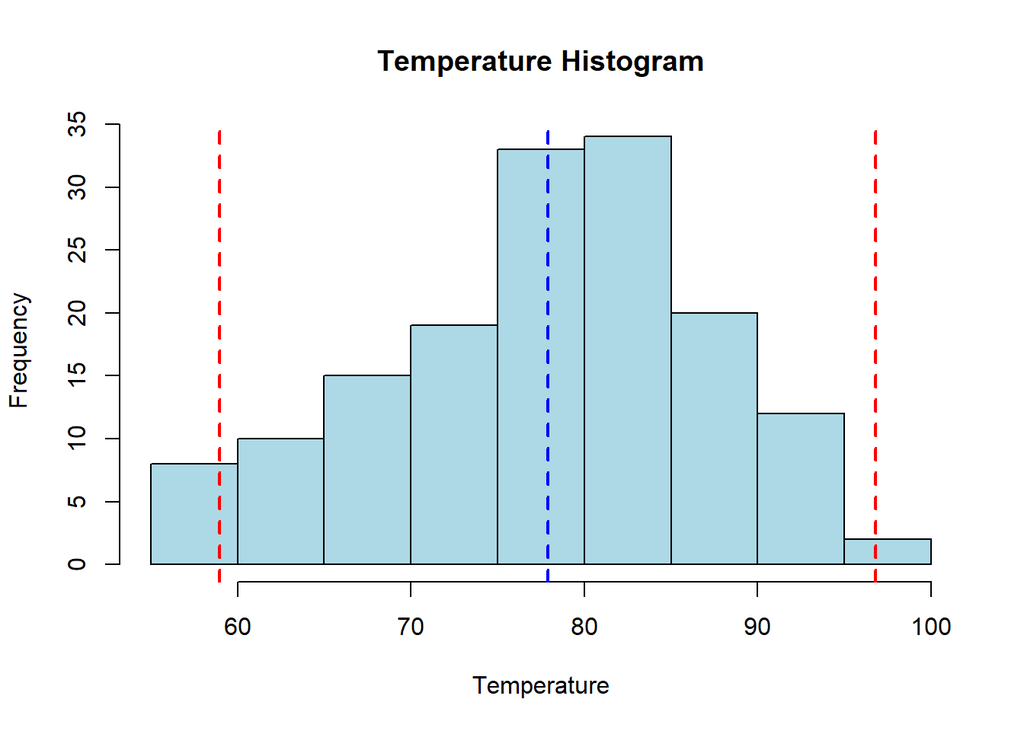

  ```r
  # Plot histogram of Temp variable
  hist(AQ$Temp, col = "lightblue", main = "Temperature Histogram", xlab = "Temperature")

  # Add vertical lines for reference range limits
  abline(v = temp_upper, col = "red", lwd = 2, lty = 2)
  abline(v = temp_lower, col = "red", lwd = 2, lty = 2)
  abline(v = mean(AQ$Temp), col = "blue", lwd = 2, lty = 2)
  ```

  ```r
  # Calculate and print number of outliers
  outliers <- AQ$Temp[AQ$Temp < temp_lower | AQ$Temp > temp_upper]
  cat("Number of outliers:", length(outliers), "\n")
  ```

  ```
  ## Number of outliers: 7
  ```

- Get the reference range of Temp variables using median and inter quartile range

  ```r
  # Calculate median and IQR of Temp variable
  temp_median <- median(AQ$Temp)
  temp_iqr <- IQR(AQ$Temp)

  # Calculate upper and lower reference range using median and IQR
  temp_upper <- temp_median + (1.5 * temp_iqr)
  temp_lower <- temp_median - (1.5 * temp_iqr)
  ```

- Plot box plot of temp variable and show the outliers of temp with reference limits

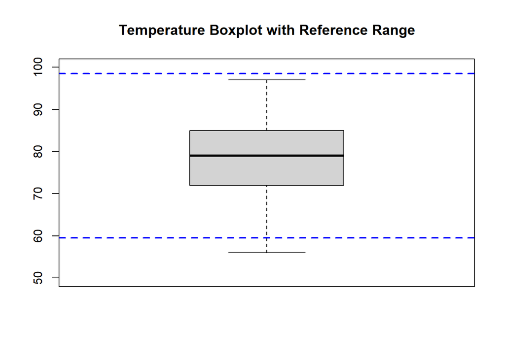

  ```r
  # Create boxplot with reference range
  boxplot(AQ$Temp, ylim = c(50,100), main="Temperature Boxplot with Reference Range")
  # Add reference range lines
  abline(h=temp_lower, lty=2, lwd=2, col="blue")
  abline(h=temp_upper, lty=2, lwd=2, col="blue")
  ```

- Which measure of central tendency and dispersion should be used for this variables

The appropriate measures of central tendency and dispersion to use for a given variable depend on the type and distribution of the data.

For the Temp variable in the airquality dataset, we can consider it a continuous variable with a roughly symmetric distribution. In this case, the most appropriate measure of central tendency is the mean, since it is the balance point of the distribution. The median can also be used as a measure of central tendency, especially if the distribution is skewed.

As for a measure of dispersion, the standard deviation is appropriate for continuous variables with roughly symmetric distributions, like the Temp variable. The interquartile range (IQR) can also be used, especially if the distribution is skewed or has outliers.

However, it is important to note that the choice of measures should also be guided by the research question and context. For example, if the data has outliers that are important for analysis, then using the mean and standard deviation might not be appropriate, and a robust measure like the median and IQR would be preferred.

**10. Do the following in R studion with the tidyverse package using R script and knit to html format**

- Define a tibble having country, year , cases and population variable with 10 random data each

  ```r
  #load the necessary library
  library(tidyverse)
  #Define a tibble having country, yearr , cases and population variable with 10 random data each
  set.seed(26)
  my_data <- tibble(
    country = sample(c("USA", "Canada", "Mexico"), 10, replace = TRUE),
    year = sample(2010:2021, 10, replace = TRUE),
    cases = sample(1000:10000, 10),
    population = sample(100000:1000000, 10)
  )
  ```

  Print the tibble

  ```r
  #print the data
  print(my_data)
  ```

  ```
  ## # A tibble: 10 × 4
  ##    country  year cases population
  ##    <chr>   <int> <int>      <int>
  ##  1 Mexico   2012  6866     832778
  ##  2 Mexico   2019  9839     826491
  ##  3 Mexico   2020  3734     756554
  ##  4 USA      2021  1012     397622
  ##  5 Mexico   2012  3304     902211
  ##  6 Canada   2015  2835     221161
  ##  7 Canada   2017  6985     917239
  ##  8 Canada   2013  6811     635890
  ##  9 Canada   2016  6606     830866
  ## 10 Canada   2012  8161     875170
  ```

- Transform this tibble to long format and intepret it carefully in terms of tidy data format

  To transform the tibble my_data to long format using the pivot_longer() function from the tidyr package:

  ```r
  # Transform the tibble to long format
  my_data_long <- pivot_longer(my_data, cols = c(cases, population),
                               names_to = "variables", values_to = "Values")

  # Print the transformed tibble
  print(my_data_long)
  ```

  ```
  ## # A tibble: 20 × 4
  ##    country  year variables  Values
  ##    <chr>   <int> <chr>       <int>
  ##  1 Mexico   2012 cases        6866
  ##  2 Mexico   2012 population 832778
  ##  3 Mexico   2019 cases        9839
  ##  4 Mexico   2019 population 826491
  ##  5 Mexico   2020 cases        3734
  ##  6 Mexico   2020 population 756554
  ##  7 USA      2021 cases        1012
  ##  8 USA      2021 population 397622
  ##  9 Mexico   2012 cases        3304
  ## 10 Mexico   2012 population 902211
  ## 11 Canada   2015 cases        2835
  ## 12 Canada   2015 population 221161
  ## 13 Canada   2017 cases        6985
  ## 14 Canada   2017 population 917239
  ## 15 Canada   2013 cases        6811
  ## 16 Canada   2013 population 635890
  ## 17 Canada   2016 cases        6606
  ## 18 Canada   2016 population 830866
  ## 19 Canada   2012 cases        8161
  ## 20 Canada   2012 population 875170
  ```

  ```r
  # Create a new tibble with transformed variables
  my_data_log <- my_data %>%
    mutate(LnCases = log(cases), LnPop = log(population))

  # Print the transformed tibble
  print(my_data_log)
  ```

  ```
  ## # A tibble: 10 × 6
  ##    country  year cases population LnCases LnPop
  ##    <chr>   <int> <int>      <int>   <dbl> <dbl>
  ##  1 Mexico   2012  6866     832778    8.83  13.6
  ##  2 Mexico   2019  9839     826491    9.19  13.6
  ##  3 Mexico   2020  3734     756554    8.23  13.5
  ##  4 USA      2021  1012     397622    6.92  12.9
  ##  5 Mexico   2012  3304     902211    8.10  13.7
  ##  6 Canada   2015  2835     221161    7.95  12.3
  ##  7 Canada   2017  6985     917239    8.85  13.7
  ##  8 Canada   2013  6811     635890    8.83  13.4
  ##  9 Canada   2016  6606     830866    8.80  13.6
  ## 10 Canada   2012  8161     875170    9.01  13.7
  ```

  This Can also be done using

  ```r
  # Create a new tibble with transformed variables
  my_data_log <- my_data
  my_data_log$LnCases <- log(my_data$cases)
  my_data_log$LnPop <- log(my_data$population)

  print(my_data_log)
  ```

  ```
  ## # A tibble: 10 × 6
  ##    country  year cases population LnCases LnPop
  ##    <chr>   <int> <int>      <int>   <dbl> <dbl>
  ##  1 Mexico   2012  6866     832778    8.83  13.6
  ##  2 Mexico   2019  9839     826491    9.19  13.6
  ##  3 Mexico   2020  3734     756554    8.23  13.5
  ##  4 USA      2021  1012     397622    6.92  12.9
  ##  5 Mexico   2012  3304     902211    8.10  13.7
  ##  6 Canada   2015  2835     221161    7.95  12.3
  ##  7 Canada   2017  6985     917239    8.85  13.7
  ##  8 Canada   2013  6811     635890    8.83  13.4
  ##  9 Canada   2016  6606     830866    8.80  13.6
  ## 10 Canada   2012  8161     875170    9.01  13.7
  ```

- Create the scatterplot of 1. case and population 2. LncCases and population 3. Cases and LnPop and 4. LnCases and LnPop in single graph window and interpret it carefully

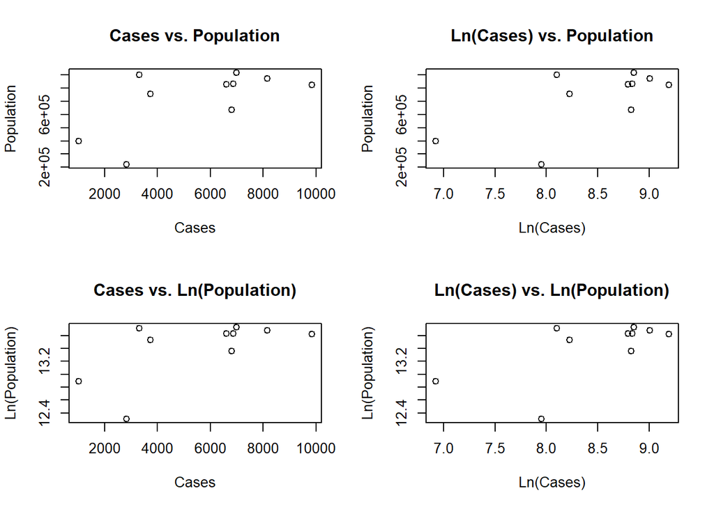

  ```r
  par(mfrow = c(2, 2))

  # Plot 1: Cases vs. Population
  plot(my_data$cases, my_data$population,
       xlab = "Cases", ylab = "Population",
       main = "Cases vs. Population")

  # Plot 2: LnCases vs. Population
  plot(my_data_log$LnCases, my_data$population,
       xlab = "Ln(Cases)", ylab = "Population",
       main = "Ln(Cases) vs. Population")

  # Plot 3: Cases vs. LnPop
  plot(my_data$cases, my_data_log$LnPop,
       xlab = "Cases", ylab = "Ln(Population)",
       main = "Cases vs. Ln(Population)")

  # Plot 4: LnCases vs. LnPop
  plot(my_data_log$LnCases, my_data_log$LnPop,
       xlab = "Ln(Cases)", ylab = "Ln(Population)",
       main = "Ln(Cases) vs. Ln(Population)")
  ```

  ```r
  par(mfrow = c(1, 1)) #1x1 plot
  ```

10. **Do as following in R studio**
- Open R and then go to help and manuals if pdf and open “An introduction to R” file
- Import this pdf file in R using Pdftools package

  ```r
  library("pdftools")
  library(tm)
  introduction_to_R <- pdf_text("C:/Program Files/R/R-4.2.2/doc/manual/R-intro.pdf")

  #Create pdf Corpus
  pdfCorpus <- Corpus(VectorSource(introduction_to_R))

  #str(pdfCorpus)
  ```

- Perform Preprocessing and create the corpus

  ```r
  # Basic cleaning of the corpus
  pdfCorpus <- tm_map(pdfCorpus, content_transformer(tolower))
  pdfCorpus <- tm_map(pdfCorpus, content_transformer(removePunctuation))
  pdfCorpus <- tm_map(pdfCorpus, content_transformer(removeNumbers))
  pdfCorpus <- tm_map(pdfCorpus, content_transformer(stripWhitespace))
  #removing unwanted html links and "\n" new line in the Corpus
  pdfCorpus <- tm_map(pdfCorpus, content_transformer(function(x) gsub("http[[:space:]]*","", x)))
  pdfCorpus <- tm_map(pdfCorpus, content_transformer(function(x) gsub("[-]","", x)))
  #inspect(pdfCorpus)

  #remove stop word from the Corpus expect the given one
  remove_pdf_Stopwords <- setdiff(stopwords("english"),c("data","big","science"))
  pdfCorpus <- tm_map(pdfCorpus, removeWords,remove_pdf_Stopwords)
  #create the Term Document Matrix with the help of Corpus "pdfCorpus"
  corpusTDM <- TermDocumentMatrix(pdfCorpus, control = list(wordLength=c(1,Inf)))
  str(corpusTDM)  #Check the structure of the TDM
  ```

  ```
  ## List of 6
  ##  $ i       : int [1:12447] 1 2 3 4 5 6 7 8 9 10 ...
  ##  $ j       : int [1:12447] 1 1 1 1 1 1 1 1 1 1 ...
  ##  $ v       : num [1:12447] 1 1 1 1 1 1 1 1 1 1 ...
  ##  $ nrow    : int 4036
  ##  $ ncol    : int 105
  ##  $ dimnames:List of 2
  ##   ..$ Terms: chr [1:4036] "analysis" "core" "data" "environment" ...
  ##   ..$ Docs : chr [1:105] "1" "2" "3" "4" ...
  ##  - attr(*, "class")= chr [1:2] "TermDocumentMatrix" "simple_triplet_matrix"
  ##  - attr(*, "weighting")= chr [1:2] "term frequency" "tf"
  ```

- find the most frequent terms and create the histogram of most freq terms

  ```r
  #Calculate the Term Frequency
  word_Freq <- findFreqTerms(corpusTDM, lowfreq = 50)
  head(word_Freq, 20)   #Display the first 20 head count
  ```

  ```
  ##  [1] "data"      "graphics"  "may"       "one"       "array"     "case"
  ##  [7] "character" "example"   "file"      "function"  "functions" "length"
  ## [13] "matrix"    "object"    "two"       "using"     "values"    "vector"
  ## [19] "vectors"   "argument"
  ```

  ```r
  #Converting the TDM to an matrix form
  m <- as.matrix(corpusTDM)
  freq_Count <- sort(rowSums(m),decreasing = T)
  head(freq_Count,20)
  ```

  ```
  ##  function       can      data    vector functions       use      used   example
  ##       269       200       194       175       147       138       132       124
  ##      will       may    matrix      file  graphics      plot      list    values
  ##       120       109       101        93        92        92        91        84
  ##    models       see   vectors      also
  ##        82        82        78        78
  ```

- create word cloud of the corpus, color it using rainbow or RColorBrewer package

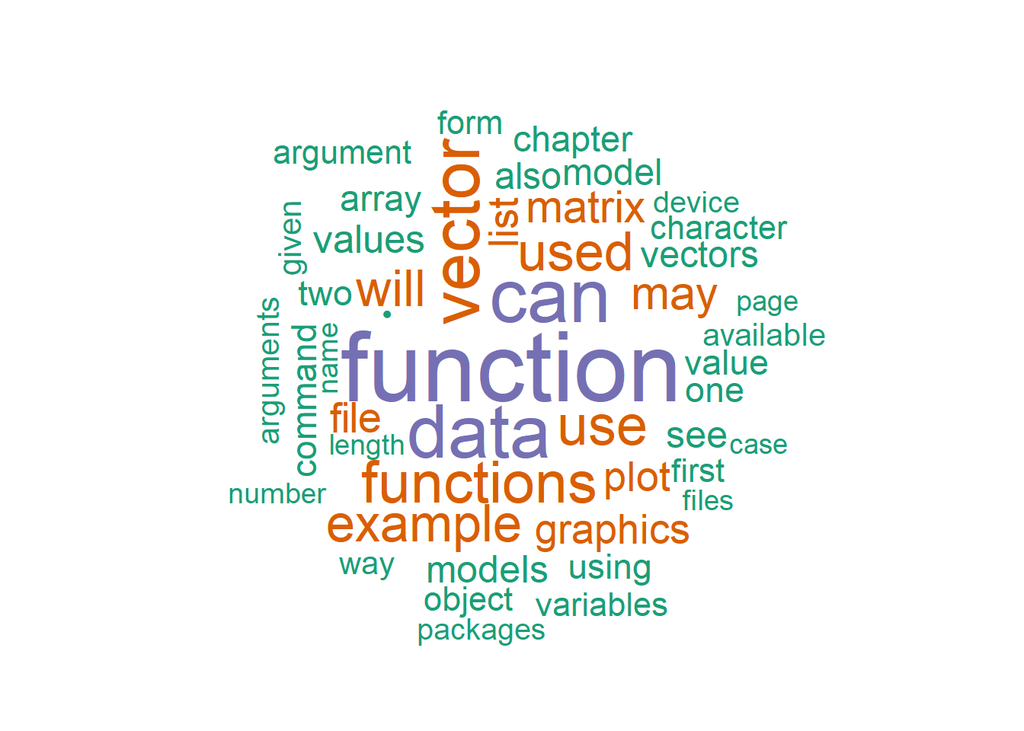

  ```r
  library(wordcloud)
  #Creating the word cloud from the text
  wordcloud(words = names(freq_Count), freq = freq_Count, min.freq = 50, random.order = FALSE, colors = brewer.pal(3,"Dark2"))
  ```

- Perform topic modeling and intepret the results carefully

  ```r
  library(topicmodels)
  #Creating the Topic Model
  set.seed(123) #to get for similar result during the run

  #set up a LDA Model
  lda_Model <- LDA(as.DocumentTermMatrix(corpusTDM), k=4)

  #getting the terms in the topic model
  terms(lda_Model, 3)
  ```

  ```
  ##      Topic 1 Topic 2    Topic 3   Topic 4
  ## [1,] "data"  "function" "can"     "function"
  ## [2,] "will"  "vector"   "file"    "plot"
  ## [3,] "use"   "example"  "command" "data"
  ```

**12 Load the igraph package in R studio and do the basic SNA as following with R Script and HTML output**

- Define g as graph object with (1,2) as its elements

  ```r
  #load the igraph package
  library(igraph)
  g <- graph(c(1,2))
  ```

- Plot the g and intepret it carefully

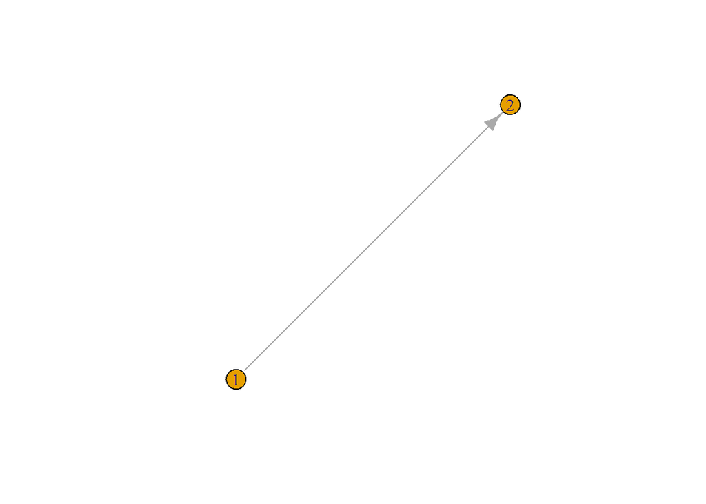

  ```r
  plot(g)
  ```

  It connect two nodes with one edge. This graph represents a simple network with two nodes and one edge. The node labeled 1 is connected to the node labeled 2.
- Define gl as graph object with (“R”,“S”,“S”,“T”,“T”,“R”,“R”,“T”,“U”, “S”) as its elements

  ```r
  #defining the graph
  gl <- graph(c("R","S","S","T","T","R","R","T","U", "S"))
  ```

- Plot gl with node color green, node sixe 30, link color as red and link sixe as f and interpret it

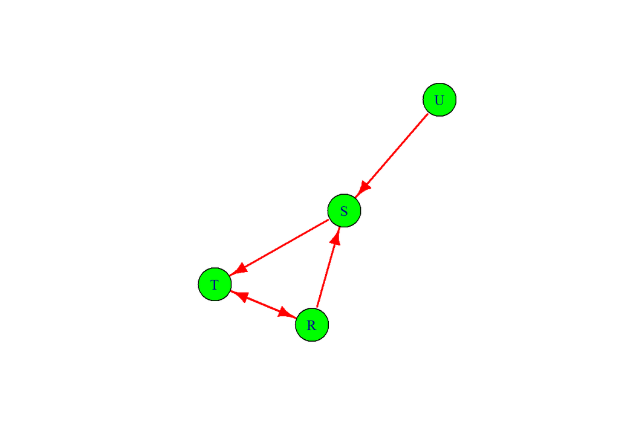

  ```r
  # Customize the visualization of gl
  V(gl)$color <- "green" # node color as green
  V(gl)$size <- 30 # node size as 30
  E(gl)$color <- "red" # link color as red
  E(gl)$width <- 2 # link width as 2

  #plotting the graph
  plot(gl)
  ```

  Here we define the graph gl and set the vertices (node) color to green (V(gl)$color <- “green” and set the size of the vertices to 30 and we set the edge color to red and edge width to 2 then we plot the graph using the plot function.
- Get degree, closeness and betweeness of gl and interpret them carefully

  ```r
  degree(gl)
  ```

  ```
  ## R S T U
  ## 3 3 3 1
  ```

  ```r
  closeness(gl)
  ```

  ```
  ##         R         S         T         U
  ## 0.5000000 0.3333333 0.3333333 0.1666667
  ```

  ```r
  betweenness(gl)
  ```

  ```
  ## R S T U
  ## 1 2 2 0
  ```

  The degree of a vertex reflects its connectivity to other vertices in the network. In this graph the degree of R , S, and T are same as 3 and the degree of U is lowest i.e 1. here U is only connected to S.

  Closeness centrality measures how close each vertex is to all other vertices in the network. A vertex with high closeness centrality is more central to the network, meaning that it can access information from other vertices more easily. Here in this graph R has the more closeness to other vertices than S and T vertices and U has the lowest closenness with other vertices

  Betweenness centrality measures how often each vertex lies on the shortest path between other vertices in the network. A vertex with high betweenness centrality is more central to the network, meaning that it has a greater influence on the flow of information or resources through the network. In this graph S and T has the betweness of 2 which means that others vertices lies in shortest path with S and T. Vertices R and S and T lies far from the vertices U.